# Using custom fonts and plotting with error bars

Author

Michael Stadler, Charlotte Soneson

## Summary

This document illustrates how to use `systemfonts` and `ragg` together with `ggplot2` to:

- make a plot that uses custom fonts
- make a plot with error bars

## Prepare data

Run the following code to prepare the data used in this document:

```r
suppressPackageStartupMessages({
    library(dplyr)
    library(tibble)
})

# built-in `mtcars` dataset (see ?mtcars)
# ... convert some columns to factors
mycars <- mtcars
mycars$cyl <- factor(mycars$cyl, levels = c("4","6","8"))
mycars$engine_shape <- factor(c("0" = "V-shaped", "1" = "straight")[as.character(mycars$vs)])
mycars$transmission <- factor(c("0" = "automatic", "1" = "manual")[as.character(mycars$am)])

# ... summarize power by cylinders
mycars_summary <- mycars |>
    group_by(cyl) |>
    summarise(hp_avg = mean(hp),
              hp_sem = sd(hp) / sqrt(length(hp)),
              .groups = "drop")

tibble(mycars)
```

```
# A tibble: 32 × 13
     mpg cyl    disp    hp  drat    wt  qsec    vs    am  gear  carb
   <dbl> <fct> <dbl> <dbl> <dbl> <dbl> <dbl> <dbl> <dbl> <dbl> <dbl>
 1  21   6      160    110  3.9   2.62  16.5     0     1     4     4
 2  21   6      160    110  3.9   2.88  17.0     0     1     4     4
 3  22.8 4      108     93  3.85  2.32  18.6     1     1     4     1
 4  21.4 6      258    110  3.08  3.22  19.4     1     0     3     1
 5  18.7 8      360    175  3.15  3.44  17.0     0     0     3     2
 6  18.1 6      225    105  2.76  3.46  20.2     1     0     3     1
 7  14.3 8      360    245  3.21  3.57  15.8     0     0     3     4
 8  24.4 4      147.    62  3.69  3.19  20       1     0     4     2
 9  22.8 4      141.    95  3.92  3.15  22.9     1     0     4     2
10  19.2 6      168.   123  3.92  3.44  18.3     1     0     4     4
# ℹ 22 more rows
# ℹ 2 more variables: engine_shape <fct>, transmission <fct>
```

```r
tibble(mycars_summary)
```

```
# A tibble: 3 × 3
  cyl   hp_avg hp_sem
  <fct>  <dbl>  <dbl>
1 4       82.6   6.31
2 6      122.    9.17
3 8      209.   13.6
```

## Create figure

### Load packages

```r
library(ggplot2)
library(ragg)
library(systemfonts)

# remark: have to set the chunk output device to "ragg_png"
knitr::opts_chunk$set(dev = "ragg_png")
```

### Get fonts

We first need to make the fonts available to `R`. Either our desired font is already installed on the local system, or we can download one of the many free fonts available on the internet, for example from https://fonts.google.com/.

The `systemfonts` package helps to list locally installed fonts that `R` can “see” or make a downloaded font file (typically a TrueType file) available to `R`.

```r
# list available fonts:
fonts <- systemfonts::system_fonts()
fonts
```

```
# A tibble: 777 × 10
   path          index name  family style weight width italic monospace variable
   <chr>         <int> <chr> <chr>  <chr> <ord>  <ord> <lgl>  <lgl>     <lgl>
 1 /System/Libr…     2 Rock… Rockw… Bold  bold   norm… FALSE  FALSE     FALSE
 2 /Users/stadl…     0 Apto… Aptos  Ligh… light  norm… TRUE   FALSE     FALSE
 3 /System/Libr…     0 Note… Notew… Light normal norm… FALSE  FALSE     FALSE
 4 /System/Libr…     1 Deva… Devan… Bold  bold   norm… FALSE  FALSE     FALSE
 5 /System/Libr…     0 Kann… Kanna… Regu… normal norm… FALSE  FALSE     FALSE
 6 /System/Libr…     0 Verd… Verda… Bold  bold   norm… FALSE  FALSE     FALSE
 7 /Users/stadl…     0 Sour… Sourc… Ital… light  norm… TRUE   TRUE      TRUE
 8 /System/Libr…     8 Aria… Arial… Light light  norm… FALSE  FALSE     FALSE
 9 /System/Libr…    10 Appl… Apple… Thin  thin   norm… FALSE  FALSE     FALSE
10 /System/Libr…     0 Deco… DecoT… Regu… normal norm… FALSE  FALSE     FALSE
# ℹ 767 more rows
```

```r
unique(fonts$family)
```

```
  [1] "Rockwell"                   "Aptos"
  [3] "Noteworthy"                 "Devanagari MT"
  [5] "Kannada Sangam MN"          "Verdana"
  [7] "Source Code Pro ExtraLight" "Arial Hebrew Scholar"
  [9] "Apple SD Gothic Neo"        "DecoType Naskh"
 [11] "Trebuchet MS"               "Khmer MN"
 [13] "PingFang SC"                "Mishafi Gold"
 [15] "Aller"                      "DejaVu Serif"
 [17] "Hasklig"                    "Inconsolata"
 [19] "Marker Felt"                "Damascus"
 [21] "Chalkduster"                "Roboto Mono"
 [23] "STIX Two Text"              "Songti TC"
 [25] "Avenir"                     "DejaVu Sans"
 [27] "Corsiva Hebrew"             "Gurmukhi Sangam MN"
 [29] "Inconsolata Expanded"       "Times New Roman"
```

[output cut: 91 more lines]

```r
# download and register an additional font
# ... already registered fonts
systemfonts::registry_fonts()
```

```
# A tibble: 0 × 7
# ℹ 7 variables: path <chr>, index <int>, family <chr>, style <chr>,
#   weight <ord>, italic <lgl>, features <list>
```

```r
# ... download Gochi Hand
download.file(url = "https://github.com/huertatipografica/gochi-hand/archive/master.zip",
              destfile = file.path(tempdir(), "master.zip"))
extracted_files <- unzip(file.path(tempdir(), "master.zip"), exdir = tempdir())
# ...  we typically want a TrueType file (extension `.ttf`)
ttf <- grep(".ttf$", extracted_files, value = TRUE)
ttf
```

```
[1] "/var/folders/qm/f4lwc7c10193k2zfy4smk22c0000gr/T//RtmpQt6hGb/gochi-hand-master/fonts/ttf/GochiHand.ttf"
```

```r
# ... register the newly downloaded font for use in R
systemfonts::register_font(name = "Gochi Hand", plain = ttf)
# ... list the now registered fonts
systemfonts::registry_fonts()
```

```
# A tibble: 4 × 7
  path                                 index family style weight italic features
  <chr>                                <int> <chr>  <chr> <ord>  <lgl>  <list>
1 /var/folders/qm/f4lwc7c10193k2zfy4s…     0 Gochi… Regu… normal FALSE  <int>
2 /var/folders/qm/f4lwc7c10193k2zfy4s…     0 Gochi… Bold  bold   FALSE  <int>
3 /var/folders/qm/f4lwc7c10193k2zfy4s…     0 Gochi… Ital… normal TRUE   <int>
4 /var/folders/qm/f4lwc7c10193k2zfy4s…     0 Gochi… Bold… bold   TRUE   <int>
```

### Plot

With the fonts available to `R`, we can now create plots that use custom fonts for some or all of the text elements. Fonts are defined by `element_text()` using the arguments `family` (see the `family` column returned by `systemfonts` functions) and `face` (one of “plain”, “italic”, “bold” or “bold.italic”, see `style` column return by `systemfonts` functions).

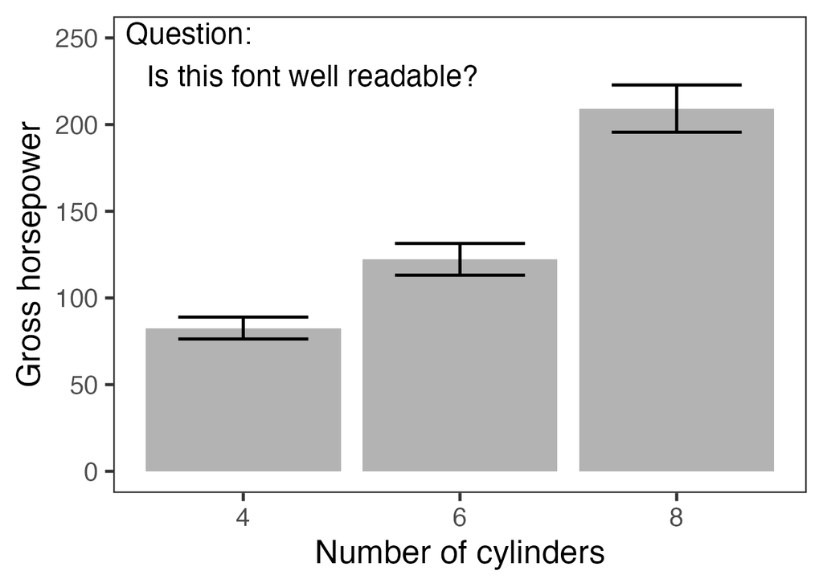

```r
# remember that this will only work if you have
# activated the `ragg` backend to render the plots

# create base plot
p0 <- ggplot(data = mycars, mapping = aes(x = cyl)) +
    coord_cartesian(ylim = c(0, 250)) +
    labs(x = "Number of cylinders", y = "Gross horsepower") +
    theme_bw(20) +
    theme(panel.grid = element_blank())

# ... add bars and Roman font
p0 +
    geom_col(data = mycars_summary, mapping = aes(y = hp_avg),
             fill = "gray70") +
    geom_errorbar(data = mycars_summary,
                  mapping = aes(ymin = hp_avg - hp_sem,
                                ymax = hp_avg + hp_sem),
                  width = 0.6) +
    annotate("text", x = -Inf, y = Inf, hjust = -0.1, vjust = 1.1,
             label = "Question:\nIs this font well readable?",
             family = "Z003", size = 18 / .pt) +
    theme(text = element_text(family = "Z003"))
```

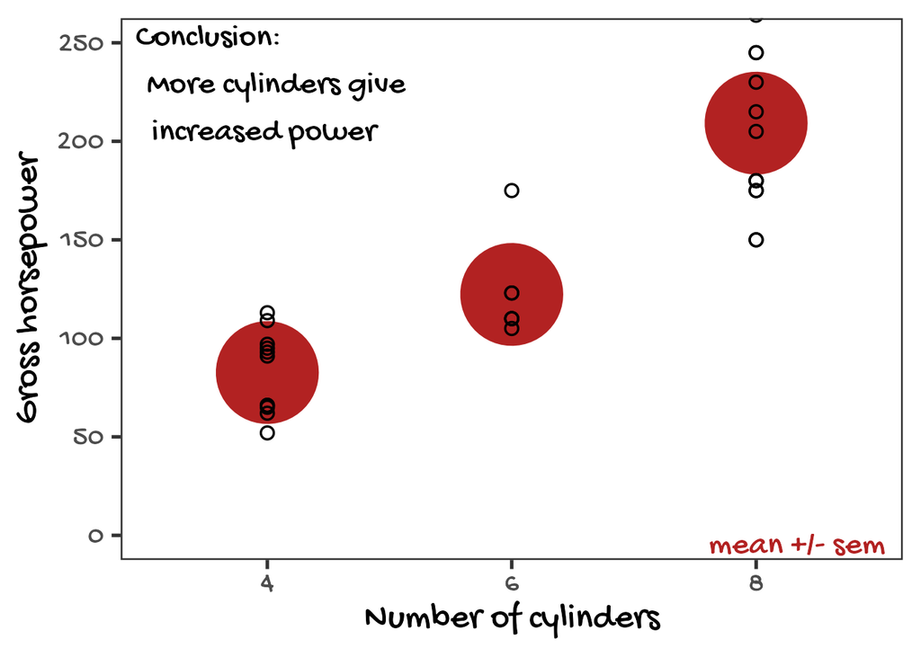

```r
# ... add points with errorbars and handwriting-style font
p0 +
    geom_pointrange(data = mycars_summary,
                    mapping = aes(y = hp_avg,
                                ymin = hp_avg - hp_sem,
                                ymax = hp_avg + hp_sem),
                    size = 6,
                    color = "firebrick") +
    geom_point(mapping = aes(y = hp), shape = 1) +
    annotate("text", x = -Inf, y = Inf, hjust = -0.1, vjust = 1.1,
             label = "Conclusion:\nMore cylinders give\n increased power",
             family = "Gochi Hand", size = 18 / .pt) +
    annotate("text", x = Inf, y = -Inf, hjust = 1.1, vjust = -0.5,
             label = "mean +/- sem", color = "firebrick",
             family = "Gochi Hand", size = 18 / .pt) +
    theme(text = element_text(family = "Gochi Hand"))
```

## Remarks

The page at https://r-graph-gallery.com/custom-fonts-in-R-and-ggplot2.html describes two ways to use custom fonts with `ggplot2`:

- [`ragg`](https://ragg.r-lib.org/) is a graphics backend (it renders the plot to a bitmap graphics device like `png()`), and can make all system fonts available to be used in R. This is the approach used above. `ragg` is based on the fast [`AGG`](https://github.com/ghaerr/agg-2.6) library, does not require you to use any other packages and is also fully integrated into RStudio (you can select is as your default graphics device in “Tools” -> “Global options…” -> “General”, panel “Graphics”).
- [`showtext`](https://github.com/yixuan/showtext) is a package that is especially designed to use custom fonts with `pdf()` devices. After loading a font and activating `showtext`, it renders the characters as filled polygons.

Another useful page with more detailed information about using fonts in `ggplot2` and `R` in general: https://yjunechoe.github.io/posts/2021-06-24-setting-up-and-debugging-custom-fonts/